# Homework2

Nik Krieger

2018-02-26

```r
library(MASS)
library(boot)
library(ISLR)
library(glmnet)
library(pls)
library(leaps)
```

# 1 Week 4 Exercises:

## 1.1 Chapter 5 - Exercise 9

#### 1.1.0.1 Task (a)

The estimate for the population mean of `medv` is the sample mean of `medv`:

```r
mean(Boston$medv)
```

```
## [1] 22.53281
```

### 1.1.1 Task (b)

The estimate for the population mean of `medv` is the sample standard deviation of `medv` divided by the square root of the sample size of `medv`.

```r
sd(Boston$medv) / sqrt(length(Boston$medv))
```

```
## [1] 0.4088611
```

### 1.1.2 Task (c)

Here is a bootstrap procedure to estimate the standard error of the population mean estimate (i.e., the sample mean) of `medv`.

```r
mean.function = function(data.vector, indices)
                return(mean(data.vector[indices]))

set.seed(0)
boot(data = Boston$medv, statistic = mean.function, R=1000)
```

```
##
## ORDINARY NONPARAMETRIC BOOTSTRAP
##
##
## Call:
## boot(data = Boston$medv, statistic = mean.function, R = 1000)
##
##
## Bootstrap Statistics :
##     original       bias    std. error
## t1* 22.53281 0.0005490119   0.3982063
```

The bootstrap procedure yielded a standard error of 0.3982063, which is only slightly less than the conventionally calculated value of 0.4088611.

### 1.1.3 Task (d)

Here is a calculated 95% confidence interval for the mean of `medv` using the standard error that the bootstrap procedure yielded (0.3982063), followed by the results of a t-test procedure performed on `medv`.

```r
conf.lower = mean(Boston$medv) - 2*0.3982063
conf.upper = mean(Boston$medv) + 2*0.3982063

conf.lower
```

```
## [1] 21.73639
```

```r
conf.upper
```

```
## [1] 23.32922
```

```r
t.test(Boston$medv)
```

```
##
##  One Sample t-test
##
## data:  Boston$medv
## t = 55.111, df = 505, p-value < 2.2e-16
## alternative hypothesis: true mean is not equal to 0
## 95 percent confidence interval:
##  21.72953 23.33608
## sample estimates:
## mean of x
##  22.53281
```

The calculated confidence interval is about (21.736, 23.329), while the t-test procedure yielded a trivially wider confidence interval of (21.729, 23.336)

### 1.1.4 Task (e)

The estimate for the population median of `medv` is the sample median of `medv`:

```r
median(Boston$medv)
```

```
## [1] 21.2
```

### 1.1.5 Task (f)

Here is a bootstrap procedure to estimate the standard error of the population median estimate (i.e., the sample mean) of `medv`.

```r
median.function = function(data.vector, indices)
                  return(median(data.vector[indices]))

set.seed(0)
boot(data = Boston$medv, statistic = median.function, R=1000)
```

```
##
## ORDINARY NONPARAMETRIC BOOTSTRAP
##
##
## Call:
## boot(data = Boston$medv, statistic = median.function, R = 1000)
##
##
## Bootstrap Statistics :
##     original  bias    std. error
## t1*     21.2  0.0069   0.3616119
```

### 1.1.6 Task (g)

The estimate for the population tenth percentile of `medv` is the sample tenth percentile of `medv`:

```r
quantile(Boston$medv, 0.1)
```

```
##   10%
## 12.75
```

### 1.1.7 Task (h)

```r
q10.function = function(data.vector, indices)
                  return(quantile(data.vector[indices], 0.1))

set.seed(0)
boot(data = Boston$medv, statistic = q10.function, R=1000)
```

```
##
## ORDINARY NONPARAMETRIC BOOTSTRAP
##
##
## Call:
## boot(data = Boston$medv, statistic = q10.function, R = 1000)
##
##
## Bootstrap Statistics :
##     original  bias    std. error
## t1*    12.75  0.0027   0.4990659
```

The procedure yielded an estimate of 0.4990659. This is markedly higher than the standard errors of the mean and median.

# 2 Week 5 Exercises

## 2.1 Chapter 6 - Exercise 9

### 2.1.1 Task (a)

First we split the data into a training and test sample (80/20).

```r
set.seed(0)
training.indices = sample(dim(College)[1], dim(College)[1]*0.8)

College.train = College[training.indices,]
College.test = College[-training.indices,]
```

### 2.1.2 Task (b)

Here we fit a linear model with the training data, predicting the number of applications received based on all other variables in the data set.

We then use this model to make predictions on the test data, and report the mean squared error (MSE).

```r
lm.model = lm(Apps ~ ., data = College.train)

lm.test.pred = predict(lm.model, College.test)

mean((College.test$Apps - lm.test.pred)^2)
```

```
## [1] 948328.5
```

### 2.1.3 Task (c)

We will now fit a ridge regression model with a lambda chosen by cross-validation. The mean square error is reported.

```r
train.matrix = model.matrix(Apps ~ ., College.train)[,-1]
 test.matrix = model.matrix(Apps ~ ., College.test)[,-1]

ridge.model = glmnet(train.matrix, College.train$Apps, alpha=0, lambda=10^seq(10, -2, length=100))

set.seed(0)
ridge.model.cv = cv.glmnet(train.matrix, College.train$Apps, alpha=0, lambda=10^seq(10, -2, length=100))

ridge.test.pred = predict(ridge.model, s=ridge.model.cv$lambda.min, newx=test.matrix)
mean((ridge.test.pred - College.test$Apps)^2)
```

```
## [1] 948010.3
```

### 2.1.4 Task (d)

```r
train.matrix = model.matrix(Apps ~ ., College.train)[,-1]
 test.matrix = model.matrix(Apps ~ .,  College.test)[,-1]

lasso.model = glmnet(train.matrix, College.train$Apps, alpha=1, lambda=10^seq(10, -2, length=100))

set.seed(0)
lasso.model.cv = cv.glmnet(train.matrix, College.train$Apps, alpha=1, lambda=10^seq(10, -2, length=100))

lasso.test.pred = predict(lasso.model, s=lasso.model.cv$lambda.min, newx=test.matrix)
mean((lasso.test.pred - College.test$Apps)^2)
```

```
## [1] 947313.9
```

```r
predict(lasso.model, type="coefficients", s=lasso.model.cv$lambda.min)
```

```
## 18 x 1 sparse Matrix of class "dgCMatrix"
##                         1
## (Intercept) -300.45287363
## PrivateYes  -477.30306704
## Accept         1.63565183
## Enroll        -1.02600761
## Top10perc     54.24140904
## Top25perc    -17.50171004
## F.Undergrad    0.06197828
## P.Undergrad    0.05502239
## Outstate      -0.08141445
## Room.Board     0.16002715
## Books          0.07968076
## Personal       0.04755280
## PhD           -9.35913985
## Terminal      -3.79319071
## S.F.Ratio     16.33743438
## perc.alumni    2.69361822
## Expend         0.06202321
## Grad.Rate      7.45242063
```

All 17 predictors have non-zero coefficients.

### 2.1.5 Task (e)

```r
set.seed(0)
pcr.model = pcr(Apps ~ ., data=College.train, scale=TRUE, validation="CV")
summary(pcr.model)
```

```
## Data:    X dimension: 621 17
##  Y dimension: 621 1
## Fit method: svdpc
## Number of components considered: 17
##
## VALIDATION: RMSEP
## Cross-validated using 10 random segments.
##        (Intercept)  1 comps  2 comps  3 comps  4 comps  5 comps  6 comps
## CV            3926     3865     2072     2060     1976     1746     1671
## adjCV         3926     3866     2069     2056     2059     1736     1665
##        7 comps  8 comps  9 comps  10 comps  11 comps  12 comps  13 comps
## CV        1647     1641     1563      1557      1561      1561      1566
## adjCV     1638     1634     1557      1553      1557      1558      1563
##        14 comps  15 comps  16 comps  17 comps
## CV         1571      1576      1260      1223
## adjCV      1567      1556      1250      1212
##
## TRAINING: % variance explained
##       1 comps  2 comps  3 comps  4 comps  5 comps  6 comps  7 comps
## X      31.520    57.04    63.76    69.37    74.85    79.89    83.50
## Apps    3.423    73.13    73.51    74.44    81.90    83.31    84.19
##       8 comps  9 comps  10 comps  11 comps  12 comps  13 comps  14 comps
## X       87.04    90.26     92.76     94.92     96.77     97.88     98.76
## Apps    84.37    85.25     85.45     85.45     85.50     85.50     85.52
##       15 comps  16 comps  17 comps
## X        99.37     99.83    100.00
## Apps     90.44     92.31     92.87
```

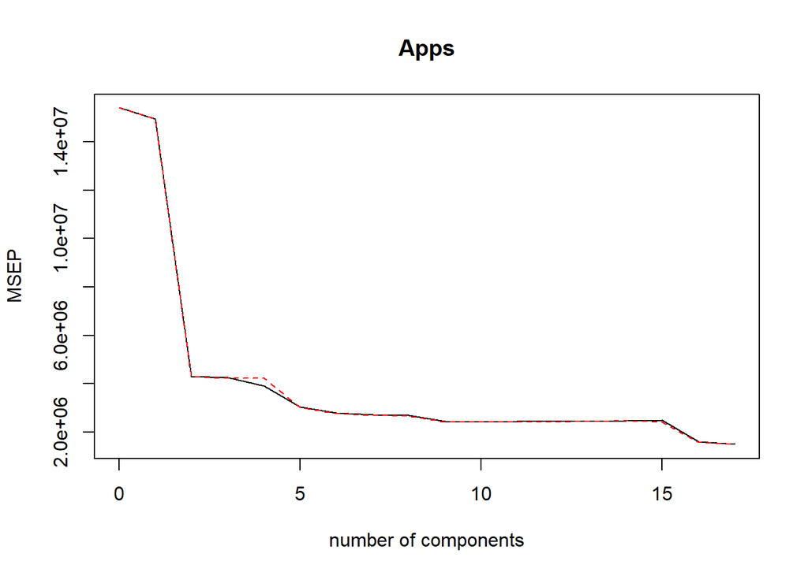

```r
validationplot(pcr.model, val.type="MSEP")
```

The lowest MSE produced by cross-validation is 1223<sup>2</sup> = 1495729, using all 17 principal components, but this is just regression. The more helpful minimum MSE is 1557<sup>2</sup>=2424249, using M=10.

So we declare that cross-validation picks M=10, and we will compute the test error using all `ncomp=10`.

```r
pcr.test.pred = predict(pcr.model, College.test, ncomp=10)
mean((pcr.test.pred - College.test$Apps)^2)
```

```
## [1] 1528997
```

### 2.1.6 Task (f)

```r
set.seed(0)
pls.model = plsr(Apps ~ ., data=College.train, scale=TRUE, validation="CV")
summary(pls.model)
```

```
## Data:    X dimension: 621 17
##  Y dimension: 621 1
## Fit method: kernelpls
## Number of components considered: 17
##
## VALIDATION: RMSEP
## Cross-validated using 10 random segments.
##        (Intercept)  1 comps  2 comps  3 comps  4 comps  5 comps  6 comps
## CV            3926     1907     1653     1512     1484     1348     1262
## adjCV         3926     1903     1654     1506     1468     1331     1249
##        7 comps  8 comps  9 comps  10 comps  11 comps  12 comps  13 comps
## CV        1245     1238     1228      1225      1223      1223      1222
## adjCV     1233     1227     1217      1214      1213      1212      1211
##        14 comps  15 comps  16 comps  17 comps
## CV         1222      1223      1223      1223
## adjCV      1212      1212      1212      1212
##
## TRAINING: % variance explained
##       1 comps  2 comps  3 comps  4 comps  5 comps  6 comps  7 comps
## X        25.8    42.83    62.21    65.05    68.48    73.02    76.55
## Apps     77.7    84.05    87.25    90.29    92.14    92.59    92.66
##       8 comps  9 comps  10 comps  11 comps  12 comps  13 comps  14 comps
## X       79.67    81.56     84.66     88.40     90.56     92.32     93.64
## Apps    92.73    92.81     92.84     92.85     92.86     92.87     92.87
##       15 comps  16 comps  17 comps
## X        96.75     97.95    100.00
## Apps     92.87     92.87     92.87
```

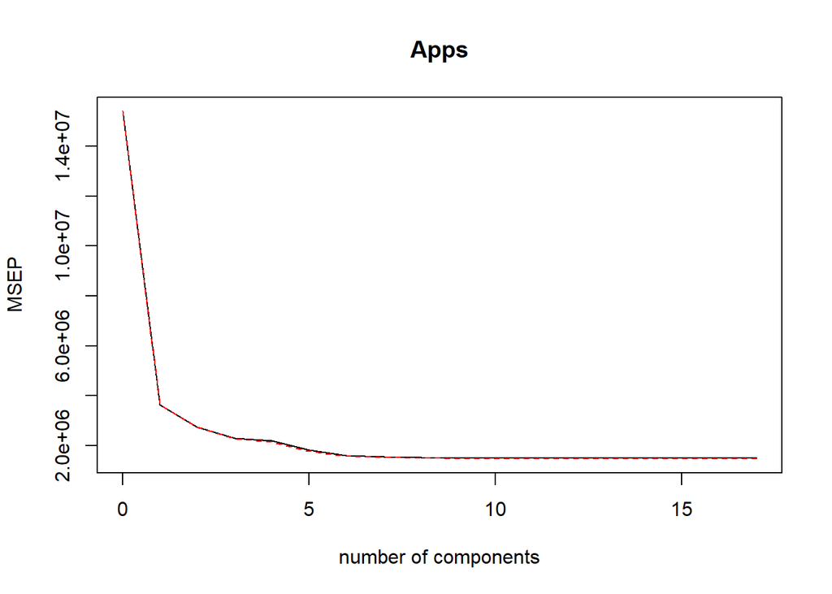

```r
validationplot(pls.model, val.type="MSEP")
```

The lowest MSE produced by cross-validation is 1222<sup>2</sup> = 1493284, using 13 principal components.

So cross-validation picks M=13, and we will compute the test error using `ncomp=13`.

```r
pls.test.pred = predict(pls.model, College.test, ncomp=13)
mean((pls.test.pred - College.test$Apps)^2)
```

```
## [1] 949978.7
```

### 2.1.7 Task (g)

We seem not to be able to predict the number of college applications very well. All test errors are around 948000, with the lasso model doing the best with a test MSE of 947313.9. The PCR model did not successfully reduce dimensionality, so it’s result was much poorer, producing a test MSE of 1528997. Other than that, there isn’t that much difference.

## 2.2 Chapter 6 - Exercise 11

### 2.2.1 Task (a)

#### 2.2.1.1 Create training and test samples

First we split the data into a training and test sample (80/20).

```r
set.seed(0)
training.indices = sample(dim(Boston)[1], dim(Boston)[1]*0.8)

Boston.train = Boston[training.indices,]
Boston.test = Boston[-training.indices,]
```

#### 2.2.1.2 Linear Model

Here we fit a linear model with the training data, predicting towns’ per capita crime rate based on all other variables in the data set.

We then use this model to make predictions on the test data, and report the mean squared error (MSE).

```r
lm.model = lm(crim ~ ., data = Boston.train)

lm.test.pred = predict(lm.model, Boston.test)

mean((Boston.test$crim - lm.test.pred)^2)
```

```
## [1] 40.89623
```

#### 2.2.1.3 Ridge Regression Model

We will now fit a ridge regression model with a lambda chosen by cross-validation. The mean square error is reported.

```r
train.matrix = model.matrix(crim ~ ., Boston.train)[,-1]
 test.matrix = model.matrix(crim ~ ., Boston.test)[,-1]

ridge.model = glmnet(train.matrix, Boston.train$crim, alpha=0, lambda=10^seq(10, -2, length=100))

set.seed(0)
ridge.model.cv = cv.glmnet(train.matrix, Boston.train$crim, alpha=0, lambda=10^seq(10, -2, length=100))

ridge.test.pred = predict(ridge.model, s=ridge.model.cv$lambda.min, newx=test.matrix)
mean((ridge.test.pred - Boston.test$crim)^2)
```

```
## [1] 41.07925
```

#### 2.2.1.4 Lasso method

We will now fit a lasso model with a lambda chosen by cross-validation. The mean square error is reported.

```r
train.matrix = model.matrix(crim ~ ., Boston.train)[,-1]
 test.matrix = model.matrix(crim ~ .,  Boston.test)[,-1]

lasso.model = glmnet(train.matrix, Boston.train$crim, alpha=1, lambda=10^seq(10, -2, length=100))

set.seed(0)
lasso.model.cv = cv.glmnet(train.matrix, Boston.train$crim, alpha=1, lambda=10^seq(10, -2, length=100))

lasso.test.pred = predict(lasso.model, s=lasso.model.cv$lambda.min, newx=test.matrix)
mean((lasso.test.pred - Boston.test$crim)^2)
```

```
## [1] 40.91244
```

#### 2.2.1.5 PCR method

```r
set.seed(0)
pcr.model = pcr(crim ~ ., data=Boston.train, scale=TRUE, validation="CV")
summary(pcr.model)
```

```
## Data:    X dimension: 404 13
##  Y dimension: 404 1
## Fit method: svdpc
## Number of components considered: 13
##
## VALIDATION: RMSEP
## Cross-validated using 10 random segments.
##        (Intercept)  1 comps  2 comps  3 comps  4 comps  5 comps  6 comps
## CV           8.609    7.170    7.164    6.797    6.797    6.809    6.867
## adjCV        8.609    7.167    7.161    6.790    6.790    6.803    6.857
##        7 comps  8 comps  9 comps  10 comps  11 comps  12 comps  13 comps
## CV       6.860    6.728    6.768     6.779     6.771     6.753     6.680
## adjCV    6.849    6.712    6.754     6.764     6.755     6.736     6.663
##
## TRAINING: % variance explained
##       1 comps  2 comps  3 comps  4 comps  5 comps  6 comps  7 comps
## X       47.48    60.28    69.36    76.43    83.17    88.22    91.45
## crim    31.22    31.54    39.09    39.35    39.43    39.70    40.03
##       8 comps  9 comps  10 comps  11 comps  12 comps  13 comps
## X       93.66    95.60     97.28     98.59     99.55    100.00
## crim    42.58    42.58     43.20     43.45     44.24     45.41
```

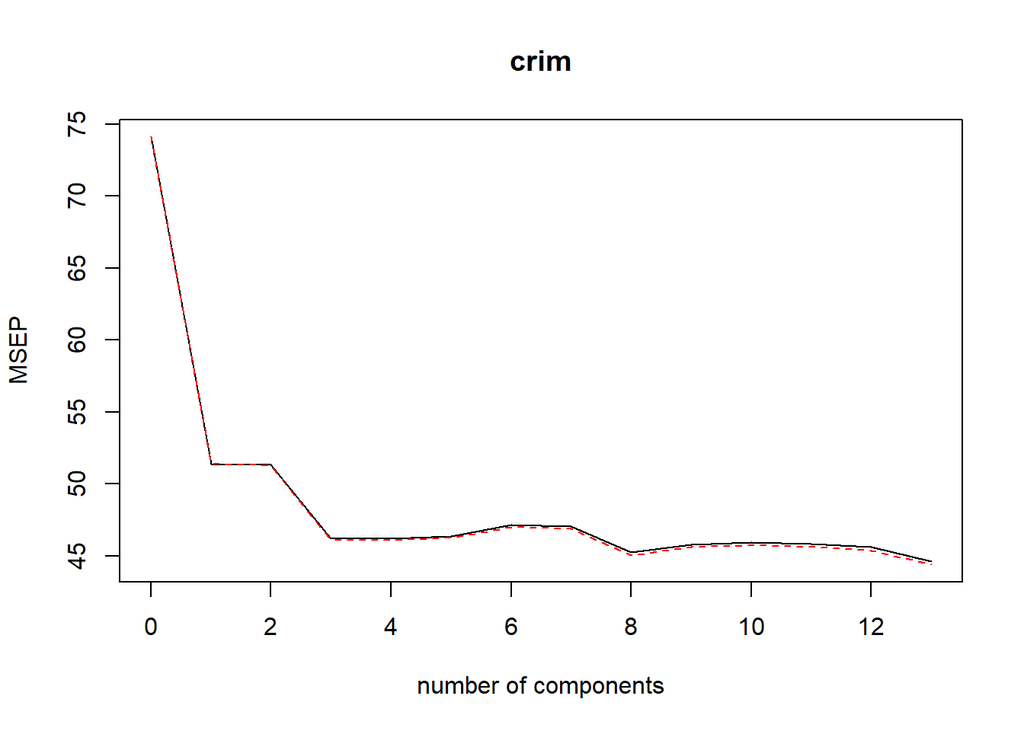

```r
validationplot(pcr.model, val.type="MSEP")
```

The lowest MSE produced by cross-validation is 6.68<sup>2</sup> = 44.6224 uses all 13 principal components, but that is just regression. The next lowest MSE, however, uses M=8 and is 6.728<sup>2</sup> = 45.266.

So we declare that cross-validation picks M=8, and we will compute the test error using all `ncomp=8`.

```r
pcr.test.pred = predict(pcr.model, Boston.test, ncomp=8)
mean((pcr.test.pred - Boston.test$crim)^2)
```

```
## [1] 42.70996
```

#### 2.2.1.6 PLSR method

```r
set.seed(0)
pls.model = plsr(crim ~ ., data=Boston.train, scale=TRUE, validation="CV")
summary(pls.model)
```

```
## Data:    X dimension: 404 13
##  Y dimension: 404 1
## Fit method: kernelpls
## Number of components considered: 13
##
## VALIDATION: RMSEP
## Cross-validated using 10 random segments.
##        (Intercept)  1 comps  2 comps  3 comps  4 comps  5 comps  6 comps
## CV           8.609    7.022    6.757    6.770    6.736    6.690    6.704
## adjCV        8.609    7.019    6.748    6.751    6.717    6.674    6.686
##        7 comps  8 comps  9 comps  10 comps  11 comps  12 comps  13 comps
## CV       6.687    6.686    6.682     6.680     6.680     6.680     6.680
## adjCV    6.669    6.668    6.664     6.662     6.663     6.663     6.663
##
## TRAINING: % variance explained
##       1 comps  2 comps  3 comps  4 comps  5 comps  6 comps  7 comps
## X       47.09    56.43    62.26    71.23    76.16    79.68    83.84
## crim    34.58    41.77    43.86    44.60    44.94    45.22    45.33
##       8 comps  9 comps  10 comps  11 comps  12 comps  13 comps
## X       86.73     89.9     95.02     96.70     98.06    100.00
## crim    45.38     45.4     45.40     45.41     45.41     45.41
```

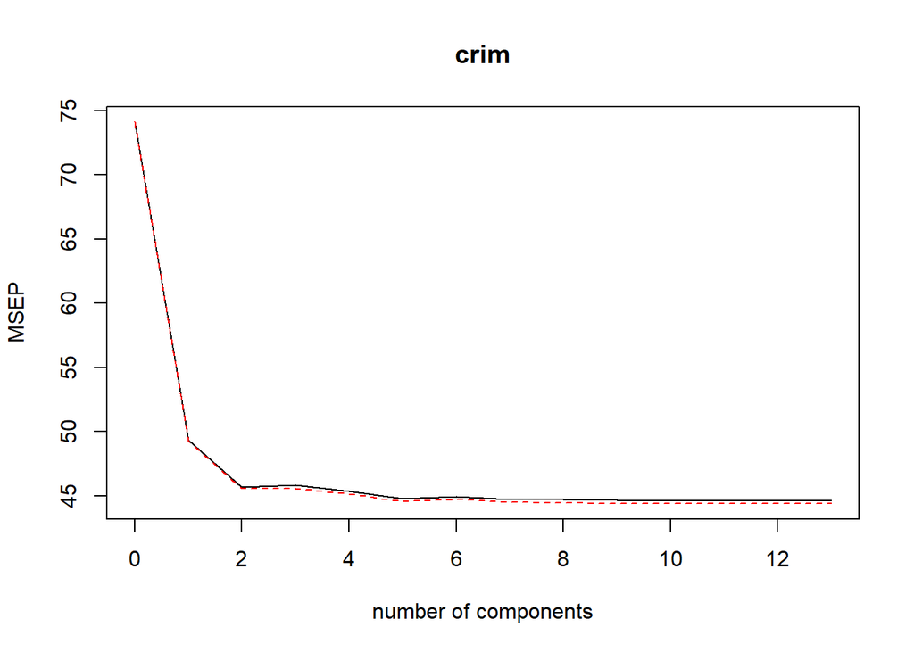

```r
validationplot(pls.model, val.type="MSEP")
```

The lowest MSE produced by cross-validation is 6.68<sup>2</sup> = 44.6224, using 10 or more principal components.

So cross-validation picks M=10, and we will compute the test error using `ncomp=10`.

```r
pls.test.pred = predict(pls.model, Boston.test, ncomp=10)
mean((pls.test.pred - Boston.test$crim)^2)
```

```
## [1] 40.87073
```

We will now use a best subset selection procedure, allowing the algorithm to consider models with up to 13 predictors.

```r
# The regsubsets predict function, courtesy of ISLR
predict.regsubsets =function(object, newdata, id,...){
  form = as.formula(object$call[[2]])
  mat = model.matrix(form, newdata)
  coefi = coef(object, id=id)
  xvars = names(coefi)
  mat[,xvars]%*%coefi
}

k=10
set.seed(0)
folds = sample(1:k, nrow(Boston), replace=TRUE)
cv.errors = matrix(NA, k, 13, dimnames=list(NULL, paste(1:13)))

for(j in 1:k){
  best.fit = regsubsets(crim ~ ., data=Boston[folds!=j,], nvmax=13)
  for(i in 1:13){
    pred=predict(best.fit, Boston[folds==j,], id=i)
    cv.errors[j,i]= mean((Boston$crim[folds==j] - pred)^2)
  }
}

mean.cv.errors=apply(cv.errors, 2, mean)
mean.cv.errors
```

```
##        1        2        3        4        5        6        7        8
## 42.25616 40.83932 40.96665 40.92546 40.33157 40.23861 39.55875 39.50477
##        9       10       11       12       13
## 39.09773 39.17212 39.14737 39.22137 39.26521
```

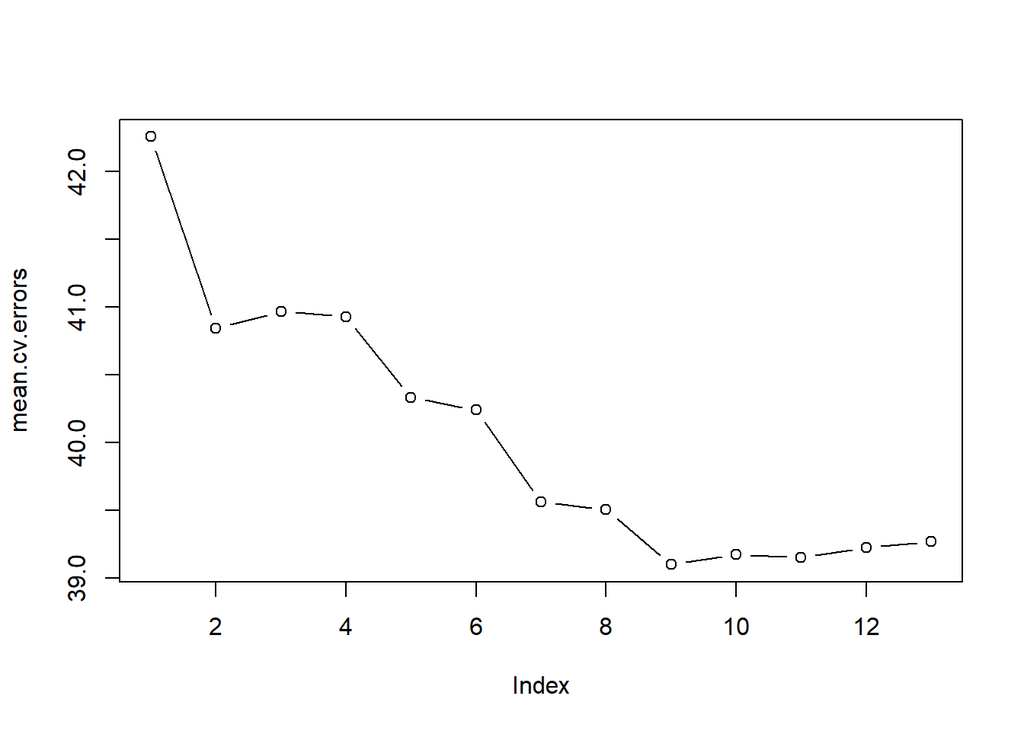

```r
par(mfrow=c(1,1))
plot(mean.cv.errors, type='b')
```

Cross-validation selects a 9-variable model, which yields a mean cross-validation error of 39.09773.

### 2.2.2 Task (b)

Here is a summary of the test MSEs produced by the different methods we used:

40.89623 Linear model 41.07925 Ridge regression 40.91244 Lasso method 42.70996 PCR method 40.87073 PLS method 39.09773 Best subsets method

All methods produced MSEs around 40. The PCR method is marginally worse, and the Best subsets method is marginally the best. My final choice would be the model produced by the best subsets method because it has the best MSE and is the most interpretable.

### 2.2.3 Task (c)

My choice only uses 9 of the 13 available predictors because the other 4 proved not to be helpful after cross-validation. In other words, when models containing these extraneous predictors were tested, they proved not to be informative for the `crim` variable–predictions that used more than 9 variables actually had higher test MSE.